# PEC2: Proyecto de visualización de datos: Familiarízate con los datos

Elena Ruiz Martinez

20 de Noviembre de 2019

# 1 Carga de los archivos de datos

```r
# Leemos y cargamos los datos
myfile <- "athlete_events.csv"
mydata <- read.csv(myfile,  stringsAsFactors = FALSE)

# Verificamos la estructura del juego de datos
str(mydata)
```

```
## 'data.frame':    271116 obs. of  15 variables:
##  $ ID    : int  1 2 3 4 5 5 5 5 5 5 ...
##  $ Name  : chr  "A Dijiang" "A Lamusi" "Gunnar Nielsen Aaby" "Edgar Lindenau Aabye" ...
##  $ Sex   : chr  "M" "M" "M" "M" ...
##  $ Age   : int  24 23 24 34 21 21 25 25 27 27 ...
##  $ Height: int  180 170 NA NA 185 185 185 185 185 185 ...
##  $ Weight: num  80 60 NA NA 82 82 82 82 82 82 ...
##  $ Team  : chr  "China" "China" "Denmark" "Denmark/Sweden" ...
##  $ NOC   : chr  "CHN" "CHN" "DEN" "DEN" ...
##  $ Games : chr  "1992 Summer" "2012 Summer" "1920 Summer" "1900 Summer" ...
##  $ Year  : int  1992 2012 1920 1900 1988 1988 1992 1992 1994 1994 ...
##  $ Season: chr  "Summer" "Summer" "Summer" "Summer" ...
##  $ City  : chr  "Barcelona" "London" "Antwerpen" "Paris" ...
##  $ Sport : chr  "Basketball" "Judo" "Football" "Tug-Of-War" ...
##  $ Event : chr  "Basketball Men's Basketball" "Judo Men's Extra-Lightweight" "Football Men's Football" "Tug-Of-War Men's Tug-Of-War" ...
##  $ Medal : chr  NA NA NA "Gold" ...
```

Para obtener también los paises, combinaremos este conjunto de datos con el archivo “noc_regions.csv”, donde tenemos las relaciones entre código NOC y país correspondiente.

```r
# Leemos y cargamos los datos
data_country <- read.csv("noc_regions.csv", stringsAsFactors = FALSE)

# Verificamos la estructura del juego de datos
str(data_country)
```

```
## 'data.frame':    230 obs. of  3 variables:
##  $ NOC   : chr  "AFG" "AHO" "ALB" "ALG" ...
##  $ region: chr  "Afghanistan" "Curacao" "Albania" "Algeria" ...
##  $ notes : chr  "" "Netherlands Antilles" "" "" ...
```

```r
# Combinamos los dos datasets por el campo NOC
data_olimpiadas<-merge (mydata, data_country, all.x = TRUE)

# Verificamos la estructura del juego de datos
str(data_olimpiadas)
```

```
## 'data.frame':    271116 obs. of  17 variables:
##  $ NOC   : chr  "AFG" "AFG" "AFG" "AFG" ...
##  $ ID    : int  132181 87371 44977 502 109153 29626 1076 121376 80210 87374 ...
##  $ Name  : chr  "Najam Yahya" "Ahmad Jahan Nuristani" "Mohammad Halilula" "Ahmad Shah Abouwi" ...
##  $ Sex   : chr  "M" "M" "M" "M" ...
##  $ Age   : int  NA NA 28 NA 24 28 28 NA NA NA ...
##  $ Height: int  NA NA 163 NA NA 168 NA NA NA NA ...
##  $ Weight: num  NA NA 57 NA 74 73 NA NA 57 NA ...
##  $ Team  : chr  "Afghanistan" "Afghanistan" "Afghanistan" "Afghanistan" ...
##  $ Games : chr  "1956 Summer" "1948 Summer" "1980 Summer" "1956 Summer" ...
##  $ Year  : int  1956 1948 1980 1956 1964 1960 1936 1956 1972 1956 ...
##  $ Season: chr  "Summer" "Summer" "Summer" "Summer" ...
##  $ City  : chr  "Melbourne" "London" "Moskva" "Melbourne" ...
##  $ Sport : chr  "Hockey" "Hockey" "Wrestling" "Hockey" ...
##  $ Event : chr  "Hockey Men's Hockey" "Hockey Men's Hockey" "Wrestling Men's Bantamweight, Freestyle" "Hockey Men's Hockey" ...
##  $ Medal : chr  NA NA NA NA ...
##  $ region: chr  "Afghanistan" "Afghanistan" "Afghanistan" "Afghanistan" ...
##  $ notes : chr  "" "" "" "" ...
```

# 2 Asignar a cada variable el tipo de variable

Por defecto al leer los ficheros con la función read.csv() se les asigna un tipo a cada variable, pero hay algunas variables que no tienen el tipo correcto, estas variables son: ID, Sex, Height y Season.

```r
data_olimpiadas$ID<- as.character(data_olimpiadas$ID)
data_olimpiadas$Sex<- as.factor(data_olimpiadas$Sex)
data_olimpiadas$Height<- as.double(data_olimpiadas$Height)
data_olimpiadas$Season<- as.factor(data_olimpiadas$Season)
data_olimpiadas$Medal<- as.factor(data_olimpiadas$Medal)

str(data_olimpiadas)
```

```
## 'data.frame':    271116 obs. of  17 variables:
##  $ NOC   : chr  "AFG" "AFG" "AFG" "AFG" ...
##  $ ID    : chr  "132181" "87371" "44977" "502" ...
##  $ Name  : chr  "Najam Yahya" "Ahmad Jahan Nuristani" "Mohammad Halilula" "Ahmad Shah Abouwi" ...
##  $ Sex   : Factor w/ 2 levels "F","M": 2 2 2 2 2 2 2 2 2 2 ...
##  $ Age   : int  NA NA 28 NA 24 28 28 NA NA NA ...
##  $ Height: num  NA NA 163 NA NA 168 NA NA NA NA ...
##  $ Weight: num  NA NA 57 NA 74 73 NA NA 57 NA ...
##  $ Team  : chr  "Afghanistan" "Afghanistan" "Afghanistan" "Afghanistan" ...
##  $ Games : chr  "1956 Summer" "1948 Summer" "1980 Summer" "1956 Summer" ...
##  $ Year  : int  1956 1948 1980 1956 1964 1960 1936 1956 1972 1956 ...
##  $ Season: Factor w/ 2 levels "Summer","Winter": 1 1 1 1 1 1 1 1 1 1 ...
##  $ City  : chr  "Melbourne" "London" "Moskva" "Melbourne" ...
##  $ Sport : chr  "Hockey" "Hockey" "Wrestling" "Hockey" ...
##  $ Event : chr  "Hockey Men's Hockey" "Hockey Men's Hockey" "Wrestling Men's Bantamweight, Freestyle" "Hockey Men's Hockey" ...
##  $ Medal : Factor w/ 3 levels "Bronze","Gold",..: NA NA NA NA NA NA NA NA NA NA ...
##  $ region: chr  "Afghanistan" "Afghanistan" "Afghanistan" "Afghanistan" ...
##  $ notes : chr  "" "" "" "" ...
```

# 3 Analizar valores vacios

```r
# Se revisa si existen atributos con valores vacíos: NA
colSums(is.na(data_olimpiadas))
```

```
##    NOC     ID   Name    Sex    Age Height Weight   Team  Games   Year
##      0      0      0      0   9474  60171  62875      0      0      0
## Season   City  Sport  Event  Medal region  notes
##      0      0      0      0 231333    370    349
```

```r
# Se revisa si existen atributos con valores vacíos: cadena vacía
colSums(data_olimpiadas=="")
```

```
##    NOC     ID   Name    Sex    Age Height Weight   Team  Games   Year
##      0      0      0      0     NA     NA     NA      0      0      0
## Season   City  Sport  Event  Medal region  notes
##      0      0      0      0     NA     NA     NA
```

- Tenemos valores vacios para **Age**, **Height** y **Weight**, no se han registrado esos datos para una serie de atletas.
- Tenemos valores vacios para **Medal** ,pero eso tiene lógica, ya que en el caso de que no se haya ganado ninguna medalla el campo queda vacio.
- Tenenos valores vacíos para **notes**, lógico ya que este campo solo se comenta en casos puntuales.
- Tenemos valores vacios para **region**, este caso es algo más raro, ya que al ir relacionado con el campo NOC, el cual no tiene ningún valor vacío, en consecuencia region tampoco debería tener ningún valor vacio. Investiguemos que atletas tienen el campo región vacio:

```r
# Buscamos las fila con que tienen el atributo region vacío.
kk <- which(is.na(data_olimpiadas$region))

# De las filas con el campo region vacio, que valor tienen en el campo NOC?
kable(unique((data_olimpiadas[kk,])$NOC))
```

| x |
| --- |
| ROT |
| SGP |
| TUV |
| UNK |

Los atletas con NOC igual a ROT, SGP, TUV o UNK tienen el campo “region”" vacio. Investigaremos por que sucede esto y si fuera necesario modificaremos el valor de este campo.

**NOC=“ROT”**

```r
# Buscamos las filas con el campo region vacio y el campo NOC="ROT"
kk_ROT<-which(is.na(data_olimpiadas$region) & (data_olimpiadas$NOC=="ROT"))
kable(data_olimpiadas[kk_ROT,])
```

|  | NOC | ID | Name | Sex | Age | Height | Weight | Team | Games | Year | Season | City | Sport | Event | Medal | region | notes |
| --- | --- | --- | --- | --- | --- | --- | --- | --- | --- | --- | --- | --- | --- | --- | --- | --- | --- |
| 198448 | ROT | 74902 | Yusra Mardini | F | 18 | 157 | 53 | Refugee Olympic Athletes | 2016 Summer | 2016 | Summer | Rio de Janeiro | Swimming | Swimming Women’s 100 metres Butterfly | NA | NA | Refugee Olympic Team |
| 198449 | ROT | 80325 | Popole Misenga | M | 24 | 180 | 90 | Refugee Olympic Athletes | 2016 Summer | 2016 | Summer | Rio de Janeiro | Judo | Judo Men’s Middleweight | NA | NA | Refugee Olympic Team |
| 198450 | ROT | 16287 | Mabika Yolande Bukasa | F | 28 | 170 | 70 | Refugee Olympic Athletes | 2016 Summer | 2016 | Summer | Rio de Janeiro | Judo | Judo Women’s Middleweight | NA | NA | Refugee Olympic Team |
| 198451 | ROT | 3515 | Paulo Amotun Lokoro | M | 24 | 170 | 61 | Refugee Olympic Athletes | 2016 Summer | 2016 | Summer | Rio de Janeiro | Athletics | Athletics Men’s 1,500 metres | NA | NA | Refugee Olympic Team |
| 198452 | ROT | 4379 | Rami Anis | M | 25 | 178 | 78 | Refugee Olympic Athletes | 2016 Summer | 2016 | Summer | Rio de Janeiro | Swimming | Swimming Men’s 100 metres Freestyle | NA | NA | Refugee Olympic Team |
| 198453 | ROT | 74902 | Yusra Mardini | F | 18 | 157 | 53 | Refugee Olympic Athletes | 2016 Summer | 2016 | Summer | Rio de Janeiro | Swimming | Swimming Women’s 100 metres Freestyle | NA | NA | Refugee Olympic Team |
| 198454 | ROT | 71113 | Rose Nathike Lokonyen | F | 21 | 157 | 50 | Refugee Olympic Athletes | 2016 Summer | 2016 | Summer | Rio de Janeiro | Athletics | Athletics Women’s 800 metres | NA | NA | Refugee Olympic Team |
| 198455 | ROT | 4379 | Rami Anis | M | 25 | 178 | 78 | Refugee Olympic Athletes | 2016 Summer | 2016 | Summer | Rio de Janeiro | Swimming | Swimming Men’s 100 metres Butterfly | NA | NA | Refugee Olympic Team |
| 198456 | ROT | 20693 | James Nyang Chiengjiek | M | 24 | 179 | 59 | Refugee Olympic Athletes | 2016 Summer | 2016 | Summer | Rio de Janeiro | Athletics | Athletics Men’s 400 metres | NA | NA | Refugee Olympic Team |
| 198457 | ROT | 71067 | Anjelina Nadai Lohalith | F | 23 | 163 | 50 | Refugee Olympic Athletes | 2016 Summer | 2016 | Summer | Rio de Janeiro | Athletics | Athletics Women’s 1,500 metres | NA | NA | Refugee Olympic Team |
| 198458 | ROT | 11364 | Yiech Pur Biel | M | 21 | 178 | 62 | Refugee Olympic Athletes | 2016 Summer | 2016 | Summer | Rio de Janeiro | Athletics | Athletics Men’s 800 metres | NA | NA | Refugee Olympic Team |
| 198459 | ROT | 60444 | Yonas Kinde | M | 36 | 172 | 57 | Refugee Olympic Athletes | 2016 Summer | 2016 | Summer | Rio de Janeiro | Athletics | Athletics Men’s Marathon | NA | NA | Refugee Olympic Team |

Vemos que corresponden a Atletas Olimpicos Refugiados, por eso tienen el campo region vacío. Dejaremos este campo vacio.

**NOC=“SGP”**

```r
# Buscamos las filas con el campo region vacio y el campo NOC="SGP"
kk_SGP<-which(is.na(data_olimpiadas$region) & (data_olimpiadas$NOC=="SGP"))
kable(head(data_olimpiadas[kk_SGP,],10))
```

|  | NOC | ID | Name | Sex | Age | Height | Weight | Team | Games | Year | Season | City | Sport | Event | Medal | region | notes |
| --- | --- | --- | --- | --- | --- | --- | --- | --- | --- | --- | --- | --- | --- | --- | --- | --- | --- |
| 210756 | SGP | 120020 | Thong Saw Pak | M | NA | NA | 67 | Singapore | 1952 Summer | 1952 | Summer | Helsinki | Weightlifting | Weightlifting Men’s Lightweight | NA | NA | NA |
| 210757 | SGP | 132853 | Yeo Gek Huat | M | NA | 175 | NA | Singapore | 1956 Summer | 1956 | Summer | Melbourne | Basketball | Basketball Men’s Basketball | NA | NA | NA |
| 210758 | SGP | 43422 | Gu Juan | F | 22 | 160 | 56 | Singapore | 2012 Summer | 2012 | Summer | London | Badminton | Badminton Women’s Singles | NA | NA | NA |
| 210759 | SGP | 97809 | Quah Ting Wen | F | 23 | 175 | 60 | Singapore | 2016 Summer | 2016 | Summer | Rio de Janeiro | Swimming | Swimming Women’s 100 metres Butterfly | NA | NA | NA |
| 210760 | SGP | 14199 | Mei Yen “Christel” Bouvron | F | 15 | 165 | 62 | Singapore | 2000 Summer | 2000 | Summer | Sydney | Swimming | Swimming Women’s 400 metres Freestyle | NA | NA | NA |
| 210761 | SGP | 14199 | Mei Yen “Christel” Bouvron | F | 15 | 165 | 62 | Singapore | 2000 Summer | 2000 | Summer | Sydney | Swimming | Swimming Women’s 200 metres Butterfly | NA | NA | NA |
| 210762 | SGP | 4264 | Ang Peng Siong | M | 21 | 180 | 75 | Singapore | 1984 Summer | 1984 | Summer | Los Angeles | Swimming | Swimming Men’s 100 metres Freestyle | NA | NA | NA |
| 210763 | SGP | 4264 | Ang Peng Siong | M | 21 | 180 | 75 | Singapore | 1984 Summer | 1984 | Summer | Los Angeles | Swimming | Swimming Men’s 4 x 100 metres Freestyle Relay | NA | NA | NA |
| 210764 | SGP | 4264 | Ang Peng Siong | M | 21 | 180 | 75 | Singapore | 1984 Summer | 1984 | Summer | Los Angeles | Swimming | Swimming Men’s 100 metres Butterfly | NA | NA | NA |
| 210765 | SGP | 4264 | Ang Peng Siong | M | 21 | 180 | 75 | Singapore | 1984 Summer | 1984 | Summer | Los Angeles | Swimming | Swimming Men’s 4 x 100 metres Medley Relay | NA | NA | NA |

Vemos que corresponden a atletas de equipos de Singapore y que no se les ha asigando ningún pais, seguramente haya alguna incoherencia entre el NOC y la region en nuestra tabla de regiones. Accederemos al archivo “noc_regions.csv” para ver si existe el NOC=“SGP”.

```r
kable(data_country[which(data_country$NOC=="SGP"),])
```

| NOC | region | notes |
| --- | --- | --- |

```r
# No aparece en la tabla de regiones, veamos ahora si la region="Singapore" y a qué NOC se la ha asignado.
kable(data_country[which(data_country$region=="Singapore"),])
```

|  | NOC | region | notes |
| --- | --- | --- | --- |
| 179 | SIN | Singapore |  |

```r
# Como ya preveíamos, tenemos un NOC diferente para la región Singapore en el archivo "athlete_events.csv" (NOC="SGP") y en el "noc_regions.csv" (NOC="SIN"), así que lo que haremos será asignar a todos los NOC="SGP" la región de "Singapore"
data_olimpiadas[kk_SGP,"region"]<-"Singapore"
```

**NOC=“TUV”**

```r
# Buscamos las filas con el campo region vacio y el campo NOC="TUV"
kk_TUV<-which(is.na(data_olimpiadas$region) & (data_olimpiadas$NOC=="TUV"))
kable(data_olimpiadas[kk_TUV,]   )
```

|  | NOC | ID | Name | Sex | Age | Height | Weight | Team | Games | Year | Season | City | Sport | Event | Medal | region | notes |
| --- | --- | --- | --- | --- | --- | --- | --- | --- | --- | --- | --- | --- | --- | --- | --- | --- | --- |
| 238050 | TUV | 86663 | Tavevele Noa | M | 20 | 176 | 74 | Tuvalu | 2012 Summer | 2012 | Summer | London | Athletics | Athletics Men’s 100 metres | NA | NA | Tuvalu |
| 238051 | TUV | 33094 | Logona Esau | M | 21 | 163 | 69 | Tuvalu | 2008 Summer | 2008 | Summer | Beijing | Weightlifting | Weightlifting Men’s Lightweight | NA | NA | Tuvalu |
| 238052 | TUV | 66655 | Tuau Lapua Lapua | M | 21 | 140 | 62 | Tuvalu | 2012 Summer | 2012 | Summer | London | Weightlifting | Weightlifting Men’s Featherweight | NA | NA | Tuvalu |
| 238053 | TUV | 120439 | Okilani Tinilau | M | 19 | NA | NA | Tuvalu | 2008 Summer | 2008 | Summer | Beijing | Athletics | Athletics Men’s 100 metres | NA | NA | Tuvalu |
| 238054 | TUV | 74540 | Asenate Manoa | F | 20 | NA | 46 | Tuvalu | 2012 Summer | 2012 | Summer | London | Athletics | Athletics Women’s 100 metres | NA | NA | Tuvalu |
| 238055 | TUV | 74540 | Asenate Manoa | F | 16 | NA | 46 | Tuvalu | 2008 Summer | 2008 | Summer | Beijing | Athletics | Athletics Women’s 100 metres | NA | NA | Tuvalu |
| 238056 | TUV | 120422 | Etimoni Timuani | M | 24 | 184 | 72 | Tuvalu | 2016 Summer | 2016 | Summer | Rio de Janeiro | Athletics | Athletics Men’s 100 metres | NA | NA | Tuvalu |

```r
# También buscamos en la tabla de regiones
kable(data_country[which(data_country$NOC=="TUV"),])
```

|  | NOC | region | notes |
| --- | --- | --- | --- |
| 209 | TUV | NA | Tuvalu |

En la tabla de regiones vemos que Tuvalu tiene el campo región vacio. Si nos informamos podremos saber que Tuvalu es uno de los 4 países que forman la polinesia. Por lo tanto el campo region lo rellenaremos con el país Tuvalu.

```r
data_olimpiadas[kk_TUV,"region"]<-'Tuvalu'
```

**NOC=“UNK”**

```r
# Buscamos las filas con el campo region vacio y el campo NOC="UNK"
kk_UNK<-which(is.na(data_olimpiadas$region) & (data_olimpiadas$NOC=="UNK"))
kable(data_olimpiadas[kk_UNK,]  )
```

|  | NOC | ID | Name | Sex | Age | Height | Weight | Team | Games | Year | Season | City | Sport | Event | Medal | region | notes |
| --- | --- | --- | --- | --- | --- | --- | --- | --- | --- | --- | --- | --- | --- | --- | --- | --- | --- |
| 241143 | UNK | 31292 | Fritz Eccard | M | NA | NA | NA | Unknown | 1912 Summer | 1912 | Summer | Stockholm | Art Competitions | Art Competitions Mixed Architecture | NA | NA | Unknown |
| 241144 | UNK | 65813 | A. Laffen | M | NA | NA | NA | Unknown | 1912 Summer | 1912 | Summer | Stockholm | Art Competitions | Art Competitions Mixed Architecture | NA | NA | Unknown |

```r
# También buscamos en la tabla de regiones
kable(data_country[which(data_country$NOC=="UNK"),])
```

|  | NOC | region | notes |
| --- | --- | --- | --- |
| 214 | UNK | NA | Unknown |

Entendemos que el valor UNK para NOC, hace referencia a que se desconoce la región de la que proviene y por lo tanto el NOC al que pertenece, en este caso dejaremos el campo NOC con ese valor.

# 4 Creamos el archivo limpio

```r
# Creamos un nuevo archivo con las modificaciones hechas
my.newfile <- "historia_olimpiadas.csv"
write.csv(data_olimpiadas, file=my.newfile, row.names = FALSE)
```

# 5 Exploramos los datos

Veamos cuantos valores únicos tenemos de cada atríbuto.

```r
# ID's únicas
length(unique(data_olimpiadas$ID))
```

```
## [1] 135571
```

```r
# Name's únicos
length(unique(data_olimpiadas$Name))
```

```
## [1] 134732
```

```r
# Team's únicos
length(unique(data_olimpiadas$Team))
```

```
## [1] 1184
```

```r
# NOC's únicos
length(unique(data_olimpiadas$NOC))
```

```
## [1] 230
```

```r
# Games's únicos
length(unique(data_olimpiadas$Games))
```

```
## [1] 51
```

```r
# Year's únicos
length(unique(data_olimpiadas$Year))
```

```
## [1] 35
```

```r
# City's únicos
length(unique(data_olimpiadas$City))
```

```
## [1] 42
```

```r
# Sport's únicos
length(unique(data_olimpiadas$Sport))
```

```
## [1] 66
```

```r
# Event's únicos
length(unique(data_olimpiadas$Event))
```

```
## [1] 765
```

```r
# region's únicos
length(unique(data_olimpiadas$region))
```

```
## [1] 208
```

Creamos un boxplot para cada una de las variables cuantitativas: Age, Weight y Height para detectar posibles valores atípicos.

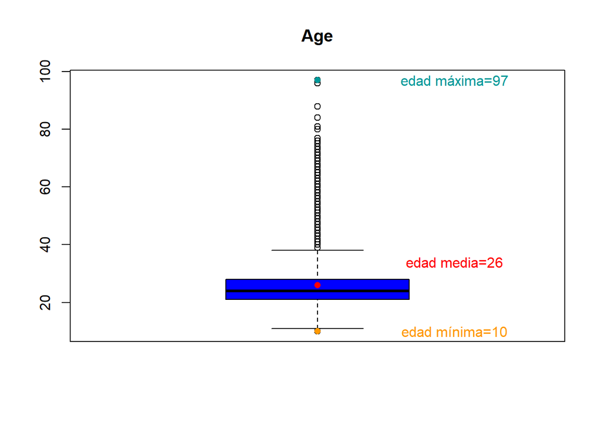

```r
# BoxPlot para la variable "Age"

media_age<-round(mean(data_olimpiadas$Age,na.rm = TRUE))
max_age<-max(data_olimpiadas$Age,na.rm = TRUE)
min_age<-min(data_olimpiadas$Age,na.rm = TRUE)

boxplot(data_olimpiadas$Age, main="Age",col="blue")
points(x = 1, y = media_age, pch =16, col="red")
text(1.3, media_age+8, labels = c(paste("edad media", media_age, sep = "=")),col = "red")

points(x = 1, y = max_age, pch =16, col="#009999")
text(1.3, max_age, labels = c(paste("edad máxima", max_age, sep = "=")),col="#009999")

points(x = 1, y = min_age, pch =16, col="#FF9900")
text(1.3, min_age, labels = c(paste("edad mínima", min_age, sep = "=")),col="#FF9900")
```

```r
# Participante más joven:
joven<-which(data_olimpiadas$Age==min_age)
kable(data_olimpiadas[joven,] )
```

|  | NOC | ID | Name | Sex | Age | Height | Weight | Team | Games | Year | Season | City | Sport | Event | Medal | region | notes |
| --- | --- | --- | --- | --- | --- | --- | --- | --- | --- | --- | --- | --- | --- | --- | --- | --- | --- |
| 117848 | GRE | 71691 | Dimitrios Loundras | M | 10 | NA | NA | Ethnikos Gymnastikos Syllogos | 1896 Summer | 1896 | Summer | Athina | Gymnastics | Gymnastics Men’s Parallel Bars, Teams | Bronze | Greece |  |

```r
# Participante más viejo:
viejo<-which(data_olimpiadas$Age==max_age)
kable(data_olimpiadas[viejo,] )
```

|  | NOC | ID | Name | Sex | Age | Height | Weight | Team | Games | Year | Season | City | Sport | Event | Medal | region | notes |
| --- | --- | --- | --- | --- | --- | --- | --- | --- | --- | --- | --- | --- | --- | --- | --- | --- | --- |
| 249358 | USA | 128719 | John Quincy Adams Ward | M | 97 | NA | NA | United States | 1928 Summer | 1928 | Summer | Amsterdam | Art Competitions | Art Competitions Mixed Sculpturing, Statues | NA | USA |  |

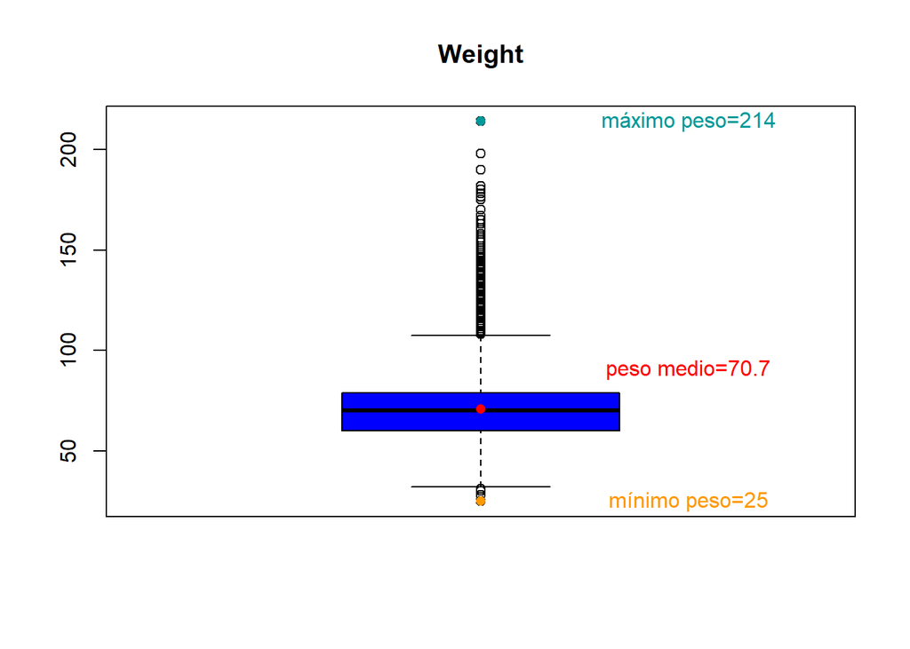

```r
# BoxPlot para la variable "Weight"

media_Weight<-round(mean(data_olimpiadas$Weight,na.rm = TRUE),1)
max_Weight<-max(data_olimpiadas$Weight,na.rm = TRUE)
min_Weight<-min(data_olimpiadas$Weight,na.rm = TRUE)

boxplot(data_olimpiadas$Weight, main="Weight",col="blue")

points(x = 1, y = media_Weight, pch =16, col="red")
text(1.3, media_Weight+20, labels = c(paste("peso medio", media_Weight, sep = "=")),col = "red")

points(x = 1, y = max_Weight, pch =16, col="#009999")
text(1.3, max_Weight, labels = c(paste("máximo peso", max_Weight, sep = "=")),col="#009999")

points(x = 1, y = min_Weight, pch =16, col="#FF9900")
text(1.3, min_Weight, labels = c(paste("mínimo peso", min_Weight, sep = "=")),col="#FF9900")
```